# ML1 small dataset - classification

Paulina Żabska & Rafał Łobacz

# Introduction

# Data preparation

Reading libraries

```r
library(tidyverse)
library(car)
library(pROC)
library(lmtest)
library(caret)
library(DMwR)
library(randomForest)
library(pROC)
```

Reading data and checking glimpse of variables.

```r
df <- read.csv('healthcare-dataset-stroke-data.csv')
glimpse(df)
```

```
## Rows: 5,110
## Columns: 12
## $ id                <int> 9046, 51676, 31112, 60182, 1665, 56669, 53882, 10...
## $ gender            <chr> "Male", "Female", "Male", "Female", "Female", "Ma...
## $ age               <dbl> 67, 61, 80, 49, 79, 81, 74, 69, 59, 78, 81, 61, 5...
## $ hypertension      <int> 0, 0, 0, 0, 1, 0, 1, 0, 0, 0, 1, 0, 0, 0, 0, 1, 0...
## $ heart_disease     <int> 1, 0, 1, 0, 0, 0, 1, 0, 0, 0, 0, 1, 0, 1, 1, 0, 1...
## $ ever_married      <chr> "Yes", "Yes", "Yes", "Yes", "Yes", "Yes", "Yes", ...
## $ work_type         <chr> "Private", "Self-employed", "Private", "Private",...
## $ Residence_type    <chr> "Urban", "Rural", "Rural", "Urban", "Rural", "Urb...
## $ avg_glucose_level <dbl> 228.69, 202.21, 105.92, 171.23, 174.12, 186.21, 7...
## $ bmi               <chr> "36.6", "N/A", "32.5", "34.4", "24", "29", "27.4"...
## $ smoking_status    <chr> "formerly smoked", "never smoked", "never smoked"...
## $ stroke            <int> 1, 1, 1, 1, 1, 1, 1, 1, 1, 1, 1, 1, 1, 1, 1, 1, 1...
```

Data have 12 columns, many of them have not appropriate data type. Firstly we will delete id variable as this has no meaning. It is just a unique label of observations. Then we will transform bmi from chr to numeric and next we check missings.

```r
#deleting id column
df <- df[,-1]
#changing bmi into numeric
df$bmi <- as.numeric(df$bmi)
#counting column missings
colSums(is.na(df)) %>%
  sort()
```

```
##            gender               age      hypertension     heart_disease
##                 0                 0                 0                 0
##      ever_married         work_type    Residence_type avg_glucose_level
##                 0                 0                 0                 0
##    smoking_status            stroke               bmi
##                 0                 0               201
```

There are some missings in bmi. We decided to perform discretization. We can divide people into normal, obese and underweight. We got thresholds from wikipedia page about bmi. Moreover we will add extra level depicting missings.

```r
#bmi sicretizition
#making foo variable
foo_bmi <- ifelse(df$bmi<18.5,"underweight",ifelse(df$bmi<30,"normal","obesity"))
foo_bmi <- ifelse(is.na(foo_bmi),"missing",foo_bmi)
df$bmi <- foo_bmi
#changing to factor
df$bmi <- as.factor(df$bmi)
#changing reference level to normal
df$bmi <- relevel(df$bmi,ref='normal')
table(df$bmi)
```

```
##
##      normal     missing     obesity underweight
##        2652         201        1920         337
```

Next we will check number of unique levels in each variable.

```r
sapply(df,
        function(x)
          unique(x) %>%
          length()) %>%
  sort()
```

```
##      hypertension     heart_disease      ever_married    Residence_type
##                 2                 2                 2                 2
##            stroke            gender               bmi    smoking_status
##                 2                 3                 4                 4
##         work_type               age avg_glucose_level
##                 5               104              3979
```

Let`s check if any variable have 0 variance.

```r
df %>% select(-stroke) %>% nearZeroVar()
```

```
## integer(0)
```

We can see that all variables should have some discriminator power. Now we will transform every variable with 2 levels to factors.

```r
#transforming 4 variables to factors
df$hypertension <- as.factor(df$hypertension)
df$heart_disease <- as.factor(df$heart_disease)
df$ever_married <- factor(as.factor(df$ever_married),labels = c(0,1))
df$Residence_type <- as.factor(df$Residence_type)
```

In gender there is 1 Other observation. We will change it to Female as there are more females in data.

```r
table(df$gender)
```

```
##
## Female   Male  Other
##   2994   2115      1
```

```r
#chaning other to female
df$gender[which(df$gender=='Other')] <- 'Female'
#making variable factor
df$gender <- factor(df$gender,labels = c(0,1))
```

Work type variable have 5 levels. One of them - never_worked occur only 22 times.

```r
table(df$work_type)
```

```
##
##      children      Govt_job  Never_worked       Private Self-employed
##           687           657            22          2925           819
```

When we check those observations we can see that they are teenagers, mostly younger than 18 y.o. We decided to merge Never_worked into children.

```r
#checking who is never_worked
df[df$work_type=='Never_worked',c('gender','age')]
```

```
##      gender age
## 254       1  14
## 604       1  23
## 887       0  19
## 940       1  13
## 960       1  17
## 1463      1  17
## 1790      0  13
## 1923      1  16
## 2347      0  14
## 2722      0  17
## 2741      1  15
## 2782      0  16
## 2918      0  18
## 3197      1  14
## 3469      1  17
## 3973      1  15
## 4069      0  16
## 4161      0  18
## 4411      1  13
## 4612      0  17
## 4773      0  18
## 4786      0  16
```

```r
#changing never_worked to children
df[df$work_type=='Never_worked','work_type'] <- 'children'
df$work_type <- as.factor(df$work_type)
df$work_type <- relevel(df$work_type,ref='Private')
```

Smoking status has 4 levels. They all have some sufficient number of occurance. Hence we will not change anything.

```r
table(df$smoking_status)
```

```
##
## formerly smoked    never smoked          smokes         Unknown
##             885            1892             789            1544
```

```r
df$smoking_status <- as.factor(df$smoking_status)
df$smoking_status <- relevel(df$smoking_status,ref='never smoked')
```

Dependent variable is very unbalanced. We will use SMOTE in training.

```r
table(df$stroke)
```

```
##
##    0    1
## 4861  249
```

```r
df$stroke <- factor(ifelse(df$stroke==1,"YES","NO"))
glimpse(df)
```

```
## Rows: 5,110
## Columns: 11
## $ gender            <fct> 1, 0, 1, 0, 0, 1, 1, 0, 0, 0, 0, 0, 0, 1, 0, 0, 1...
## $ age               <dbl> 67, 61, 80, 49, 79, 81, 74, 69, 59, 78, 81, 61, 5...
## $ hypertension      <fct> 0, 0, 0, 0, 1, 0, 1, 0, 0, 0, 1, 0, 0, 0, 0, 1, 0...
## $ heart_disease     <fct> 1, 0, 1, 0, 0, 0, 1, 0, 0, 0, 0, 1, 0, 1, 1, 0, 1...
## $ ever_married      <fct> 1, 1, 1, 1, 1, 1, 1, 0, 1, 1, 1, 1, 1, 1, 1, 1, 1...
## $ work_type         <fct> Private, Self-employed, Private, Private, Self-em...
## $ Residence_type    <fct> Urban, Rural, Rural, Urban, Rural, Urban, Rural, ...
## $ avg_glucose_level <dbl> 228.69, 202.21, 105.92, 171.23, 174.12, 186.21, 7...
## $ bmi               <fct> obesity, missing, obesity, obesity, normal, norma...
## $ smoking_status    <fct> formerly smoked, never smoked, never smoked, smok...
## $ stroke            <fct> YES, YES, YES, YES, YES, YES, YES, YES, YES, YES,...
```

As our data is ready to use, we will partition it into 70% train and 30% test.

```r
set.seed(987654321)
#splitting data
data_which_train <- createDataPartition(df$stroke, # target variable
                                          # share of the training sample
                                          p = 0.7,
                                          # should result be a list?
                                          list = FALSE)
df_train <- df[data_which_train,]
df_test <- df[-data_which_train,]
summary(df_train$stroke)
```

```
##   NO  YES
## 3403  175
```

```r
summary(df_test$stroke)
```

```
##   NO  YES
## 1458   74
```

# Feature Selection & data transformation

Firstly we will plot histogram of numeric variable, maybe there are some outilers or they need transformation.

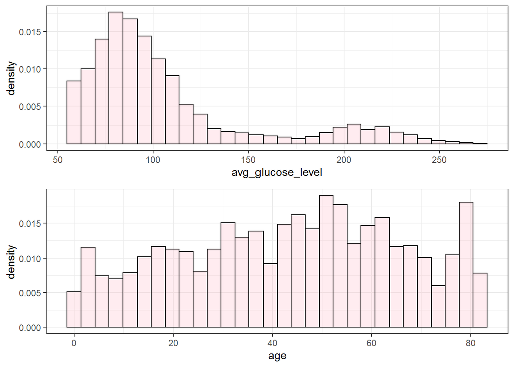

```r
#creating histograms; saving them and ploting in grid
p1 <- ggplot(df_train,aes(avg_glucose_level)) +
  geom_histogram(aes(y=..density..),fill='pink',col='black',alpha=0.3, position="identity")   + theme_bw()
p2 <-ggplot(df_train,aes(age)) +
  geom_histogram(aes(y=..density..),fill='pink',col='black',alpha=0.3, position="identity")   + theme_bw()
gridExtra::grid.arrange(p1,p2)
```

```r
set.seed(987654321)
#fitting random forest on train data
rf_model <- randomForest(stroke~.,df_train)
#checking variable improtance using GINI
importance(rf_model) %>%
  data.frame() %>% arrange(desc(MeanDecreaseGini))
```

```
##                   MeanDecreaseGini
## avg_glucose_level        96.984347
## age                      77.747067
## smoking_status           26.142377
## bmi                      19.682803
## work_type                17.720365
## Residence_type           11.276888
## gender                   10.311076
## hypertension              9.848530
## heart_disease             8.606660
## ever_married              7.258597
```

```r
set.seed(987654321)
#using SMOTE on train data
df_smote <- SMOTE(stroke ~ ., df_train)
table(df_smote$stroke)
```

```
##
##  NO YES
## 700 525
```

Data is not perfectly balanced but we wanted too avoid issues with to much upsampling or to much downsampling.  
For training we will use 5-Fold Cross Validation 3 times.

```r
options(contrasts = c("contr.treatment",  # for non-ordinal factors
                      "contr.treatment")) # for ordinal factors
#setting up cross-validation
ctrl_cv5x3 <- trainControl(method = "repeatedcv",
                           number = 5,
                           repeats = 3,
                         classProbs = TRUE,
                        summaryFunction = twoClassSummary)
```

# Training

```r
#fitting logit
set.seed(987654321)
log_model <- train(stroke ~ .,
        data = df_smote,
        method = "glm",
        family = "binomial",
        trControl = ctrl_cv5x3,
        metric='ROC')

#predicting train data from model obtained from cross-validation logit
train_log = predict(log_model,type = "prob")
#counting AUCROC
train_log_roc = roc(df_smote$stroke ~ train_log[,2], plot = FALSE, print.auc = FALSE)
#predicting test data
test_log = predict(log_model,df_test,type = "prob")
#counting AUCROC
test_log_roc = roc(df_test$stroke ~ test_log[,2], plot = FALSE, print.auc = FALSE)
#storing cross-validation AUCROC
vec_valid <- mean(log_model$resample$ROC)
#storing train prediction AUCROC
vec_train <- train_log_roc$auc
#storing test prediction AUCROC
vec_test <- test_log_roc$auc

#everything below follows the same procedure so I`m not gonna comment every model
#only difference could be some additional parameters tuning

#k-nearest neighbors
set.seed(987654321)
different_k <- data.frame(k = 117)
knn_model <-
  train(stroke ~ .,
        data = df_smote,
        method = "knn",
        trControl = ctrl_cv5x3,
        tuneGrid = different_k,
        preProcess = c("range"),
        #preProcess = c("center","scale"),
        metric='ROC')

train_knn = predict(knn_model,type = "prob")
train_knn_roc = roc(df_smote$stroke ~ train_knn[,2], plot = FALSE, print.auc = FALSE)
test_knn = predict(knn_model,df_test,type = "prob")
test_knn_roc = roc(df_test$stroke ~ test_knn[,2], plot = FALSE, print.auc = FALSE)
vec_valid <- rbind(vec_valid,mean(knn_model$resample$ROC))
vec_train <- rbind(vec_train,train_knn_roc$auc)
vec_test <- rbind(vec_test,test_knn_roc$auc)

#SVM
set.seed(987654321)
parametersC <- data.frame(C = 0.1)
svm_model <- train(stroke~.,
                           data = df_smote,
                           method = "svmLinear",
                           metric = 'ROC',
                           tuneGrid = parametersC,
                           trControl = ctrl_cv5x3)

train_svm = predict(svm_model,type = "prob")
train_svm_roc = roc(df_smote$stroke ~ train_svm[,2], plot = FALSE, print.auc = FALSE)
test_svm = predict(svm_model,df_test,type = "prob")
test_svm_roc = roc(df_test$stroke ~ test_svm[,2], plot = FALSE, print.auc = FALSE)
vec_valid <- rbind(vec_valid,mean(svm_model$resample$ROC))
vec_train <- rbind(vec_train,train_svm_roc$auc)
vec_test <- rbind(vec_test,test_svm_roc$auc)

#Random Forest
tgrid <- expand.grid(
  .mtry = 6,
  .splitrule = "gini",
  .min.node.size = 2
)
set.seed(987654321)
rf_gridsearch <- train(stroke ~ .,
                       data = df_smote,
                       method = 'ranger',
                       metric = 'ROC',
                       tuneGrid = tgrid,
                       trControl = ctrl_cv5x3)

train_rf= predict(rf_gridsearch,type = "prob")
train_rf_roc = roc(df_smote$stroke ~ train_rf[,2], plot = FALSE, print.auc = FALSE)
test_rf = predict(rf_gridsearch,df_test,type = "prob")
test_rf_roc = roc(df_test$stroke ~ test_rf[,2], plot = FALSE, print.auc = FALSE)
vec_valid <- rbind(vec_valid,mean(rf_gridsearch$resample$ROC))
vec_train <- rbind(vec_train,train_rf_roc$auc)
vec_test <- rbind(vec_test,test_rf_roc$auc)

#linear discriminant analysis
set.seed(987654321)
lda_model <- train(stroke ~ .,
        data = df_smote,
        method = "lda",
        family = "binomial",
        trControl = ctrl_cv5x3,
        metric='ROC')

train_lda= predict(lda_model,type = "prob")
train_lda_roc = roc(df_smote$stroke ~ train_lda[,2], plot = FALSE, print.auc = FALSE)
test_lda = predict(lda_model,df_test,type = "prob")
test_lda_roc = roc(df_test$stroke ~ test_lda[,2], plot = FALSE, print.auc = FALSE)
vec_valid <- rbind(vec_valid,mean(lda_model$resample$ROC))
vec_train <- rbind(vec_train,train_lda_roc$auc)
vec_test <- rbind(vec_test,test_lda_roc$auc)

#Extreme Gradient Boosting
set.seed(987654321)
tune_grid <- expand.grid(nrounds = 200,
                        max_depth = 4,
                        eta = 0.05,
                        gamma = 0,
                        colsample_bytree = 0.5,
                        min_child_weight = 0,
                        subsample = 0.5)

xgb_fit <- train(stroke ~., data = df_smote, method = "xgbTree",
                trControl=ctrl_cv5x3,
                tuneGrid = tune_grid,
                tuneLength = 10,
                metric='ROC')
train_xgb= predict(xgb_fit,type = "prob")
train_xgb_roc = roc(df_smote$stroke ~ train_xgb[,2], plot = FALSE, print.auc = FALSE)
test_xgb = predict(xgb_fit,df_test,type = "prob")
test_xgb_roc = roc(df_test$stroke ~ test_xgb[,2], plot = FALSE, print.auc = FALSE)
vec_valid <- rbind(vec_valid,mean(xgb_fit$resample$ROC))
vec_train <- rbind(vec_train,train_xgb_roc$auc)
vec_test <- rbind(vec_test,test_xgb_roc$auc)

#Neural Network
set.seed(987654321)
nnet_fit <- train(stroke ~., data = df_smote, method = "nnet",
                trControl=ctrl_cv5x3,
                 maxit=3000,
                preProcess = c('center', 'scale'),
                metric='ROC',
                trace=FALSE,
                tuneGrid=expand.grid(size=1, decay=c(0.1,0.5,1,5)))
train_nn= predict(nnet_fit,type = "prob")
train_nn_roc = roc(df_smote$stroke ~ train_nn[,2], plot = FALSE, print.auc = FALSE)
test_nn = predict(nnet_fit,df_test,type = "prob")
test_nn_roc = roc(df_test$stroke ~ test_nn[,2], plot = FALSE, print.auc = FALSE)
vec_valid <- rbind(vec_valid,mean(nnet_fit$resample$ROC))
vec_train <- rbind(vec_train,train_nn_roc$auc)
vec_test <- rbind(vec_test,test_nn_roc$auc)

#Elastic Net
set.seed(987654321)
parameters_elastic2 <- expand.grid(alpha = 0.1,
                                   lambda = 0.01)

glm_fit <- train(stroke ~., data = df_smote, method = "glmnet",
                trControl=ctrl_cv5x3,
                metric='ROC',
                tuneGrid = parameters_elastic2
                )
train_glm= predict(glm_fit,type = "prob")
train_glm_roc = roc(df_smote$stroke ~ train_glm[,2], plot = FALSE, print.auc = FALSE)
test_glm = predict(glm_fit,df_test,type = "prob")
test_glm_roc = roc(df_test$stroke ~ test_glm[,2], plot = FALSE, print.auc = FALSE)
vec_valid <- rbind(vec_valid,mean(glm_fit$resample$ROC))
vec_train <- rbind(vec_train,train_glm_roc$auc)
vec_test <- rbind(vec_test,test_glm_roc$auc)

#Adaboost
set.seed(987654321)
Grid <- expand.grid(maxdepth=5,nu=0.1,iter=150)
ada_fit = train(x=df_smote[,-11],y=df_smote[,11], method="ada",
                    trControl = ctrl_cv5x3,metric='ROC',
                    tuneGrid=Grid)
train_ada= predict(ada_fit,type = "prob")
train_ada_roc = roc(df_smote$stroke ~ train_ada[,2], plot = FALSE, print.auc = FALSE)
test_ada = predict(ada_fit,df_test,type = "prob")
test_ada_roc = roc(df_test$stroke ~ test_ada[,2], plot = FALSE, print.auc = FALSE)
vec_valid <- rbind(vec_valid,mean(ada_fit$resample$ROC))
vec_train <- rbind(vec_train,train_ada_roc$auc)
vec_test <- rbind(vec_test,test_ada_roc$auc)

#Gradient Boosting
set.seed(987654321)
gbm_fit <- train(stroke ~ ., data = df_smote,
                 method = "gbm",
                 metric='ROC',
                 trControl = ctrl_cv5x3,

                 verbose = FALSE)
train_gbm= predict(gbm_fit,type = "prob")
train_gbm_roc = roc(df_smote$stroke ~ train_gbm[,2], plot = FALSE, print.auc = FALSE)
test_gbm = predict(gbm_fit,df_test,type = "prob")
test_gbm_roc = roc(df_test$stroke ~ test_gbm[,2], plot = FALSE, print.auc = FALSE)
vec_valid <- rbind(vec_valid,mean(gbm_fit$resample$ROC))
vec_train <- rbind(vec_train,train_gbm_roc$auc)
vec_test <- rbind(vec_test,test_gbm_roc$auc)

#Regularized discriminant analysis
set.seed(987654321)
rdaGrid = expand.grid(gamma = (0:4)/4, lambda = c(0.5,3/4,1))

rda_fit <- train(stroke ~ ., data = df_smote,
                 method = "rda",
                 metric='ROC',
                 trControl = ctrl_cv5x3,
                 tuneGrid  = rdaGrid)
train_rda= predict(rda_fit,type = "prob")
train_rda_roc = roc(df_smote$stroke ~ train_rda[,2], plot = FALSE, print.auc = FALSE)
test_rda = predict(rda_fit,df_test,type = "prob")
test_rda_roc = roc(df_test$stroke ~ test_rda[,2], plot = FALSE, print.auc = FALSE)
vec_valid <- rbind(vec_valid,mean(rda_fit$resample$ROC))
vec_train <- rbind(vec_train,train_rda_roc$auc)
vec_test <- rbind(vec_test,test_rda_roc$auc)

#Partial Least Squared
set.seed(987654321)
pls_fit <- train(stroke ~ ., data = df_smote,
                 method = "pls",
                 metric='ROC',
                 preProc = c("center", "scale"),
                 tuneLength = 10,
                 maxit=1000,
                 trControl = ctrl_cv5x3
                 )
train_pls= predict(pls_fit,type = "prob")
train_pls_roc = roc(df_smote$stroke ~ train_pls[,2], plot = FALSE, print.auc = FALSE)
test_pls = predict(pls_fit,df_test,type = "prob")
test_pls_roc = roc(df_test$stroke ~ test_pls[,2], plot = FALSE, print.auc = FALSE)
vec_valid <- rbind(vec_valid,mean(pls_fit$resample$ROC))
vec_train <- rbind(vec_train,train_pls_roc$auc)
vec_test <- rbind(vec_test,test_pls_roc$auc)
```

After all models are trained we are going to create matrix of results.

```r
#column binding train prediction,cross-validation and test prediction results
df_results <- cbind(vec_train,vec_valid,vec_test)
#changing rownames
rownames(df_results) <- c('logit','knn','svm','rf','lda', 'xgb','nnet','elastic',
                          'ada','gbm','rda','pls')
#changing colnames
colnames(df_results) <- c('train','cross_validation','test')
```

On the plot below we can see cross-validation results. Firstly we can spot that KNN is the worst model, AUCROC is only equal to 0.84 and lag behind others. Next we have group of models that have very similar performance. In this group there is SVM, logit, pls, lda and even some simple neural network. Their AUCROC is between 0.875-0.876. The best methods turned out to be tree based models. Their AUCROC performance is between 0.894 and 0.905. Although, they can be easily over fitted.

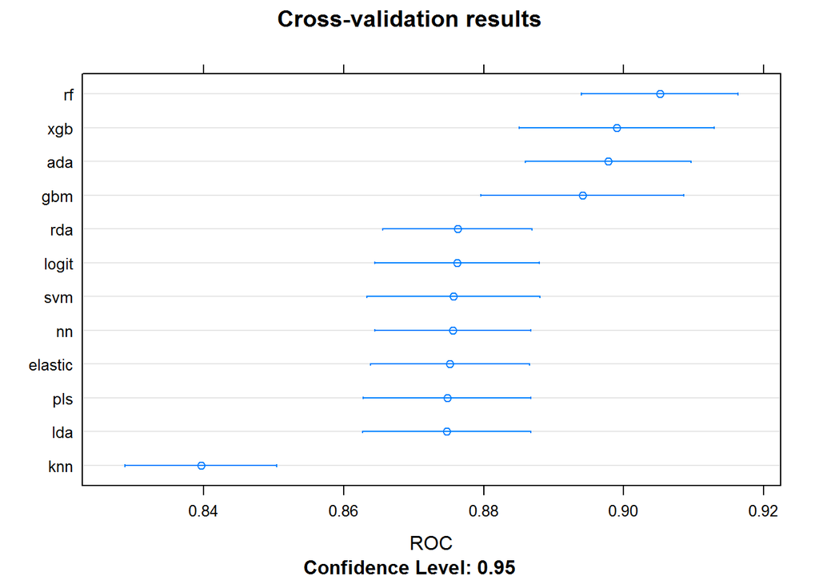

```r
#storing list of resamples to make dotplot of cross-validation AUCROC results
cvValues <- resamples(list(ada = ada_fit, elastic = glm_fit,nn=nnet_fit,
                           xgb=xgb_fit,svm=svm_model,knn=knn_model,
                           lda=lda_model,logit=log_model,rf=rf_gridsearch,
                           gbm=gbm_fit,rda=rda_fit,pls=pls_fit))
#ploting results of models cross-validation results
dotplot(cvValues, metric = "ROC", main = 'Cross-validation results')
```

Now let`s check how the models predict out of sample data. As, we can see in the table all the models have lower performance on test data. KNN is still the worst. Test AUCROC for tree models dropped significantly by more or less 0.06. Their test performance is worse than those algorithms in the middle like logit, lda or pls. This indicates that tree based model over fitted the data. There might me many reasons for that. For example, they spotted some non-linearities that actually were not true. Another thing is that after using SMOTE, data sample was small and they could produce biased estimate. Knowing that there exist bias-variance trade off, on test data they did way worse. The best models on test data were Partial Least Square and Linear Discriminant Analysis. Their AUCROC was equal to 0.863.

```r
#printing table of train/cross-validation/test results
df_results %>% as.data.frame() %>% arrange(desc(cross_validation)) %>%
  kableExtra::kbl(digits = 3,caption = 'AUCROC') %>%
  kableExtra::kable_classic("striped", full_width = F)
```

AUCROC

|  | train | cross_validation | test |
| --- | --- | --- | --- |
| rf | 1.000 | 0.905 | 0.833 |
| xgb | 0.963 | 0.899 | 0.832 |
| ada | 0.964 | 0.898 | 0.841 |
| gbm | 0.930 | 0.894 | 0.832 |
| rda | 0.888 | 0.876 | 0.851 |
| logit | 0.884 | 0.876 | 0.854 |
| svm | 0.883 | 0.876 | 0.857 |
| nnet | 0.884 | 0.876 | 0.854 |
| elastic | 0.883 | 0.875 | 0.861 |
| pls | 0.882 | 0.875 | 0.863 |
| lda | 0.882 | 0.875 | 0.863 |
| knn | 0.845 | 0.840 | 0.825 |

# Summary

To sum up, we could see that even though the data was simple and small, there were many obstacles and coming to conclusion which model is the best is not clear. To help us better understand why tree base models over fitted the data, we could use XAI(explainable artificial intelligence). When it comes to results, cross-validation clearly state that Random Forest is the best but there is dropdown in test performance in comparison to simpler methods like lda or logit. If we would have to choose the best model for this data we would choose logit. It is very fast, simple and interpretable approach that still got pretty nice performance.